# MI part markdown

### Countries that got deleted from the list at the first glance

Please let me know if any of these countries is needed so I can add them back

```
## [1] "Trinidad and Tobago" "Colombia"            "Cyprus"
## [4] "Moldova"             "Mali"                "Burkina Faso"
## [7] "Zambia"              "Taiwan"              "New Zealand"
```

## Plots of distributions of answers by country

> Mainly to inspect the distribution of nonnormal values (-5, -2, -1) Especially, -2: No answer and -1:Dont know are pretty prevalent in some countries.

This is the density plot for the V152 “tax the rich,” **Colombia** has ALL of answers as -4 “Not asked.” Thus it has been dropped as well. After deleting Colombia, **Georgia** has 14.4& of nonnormal values

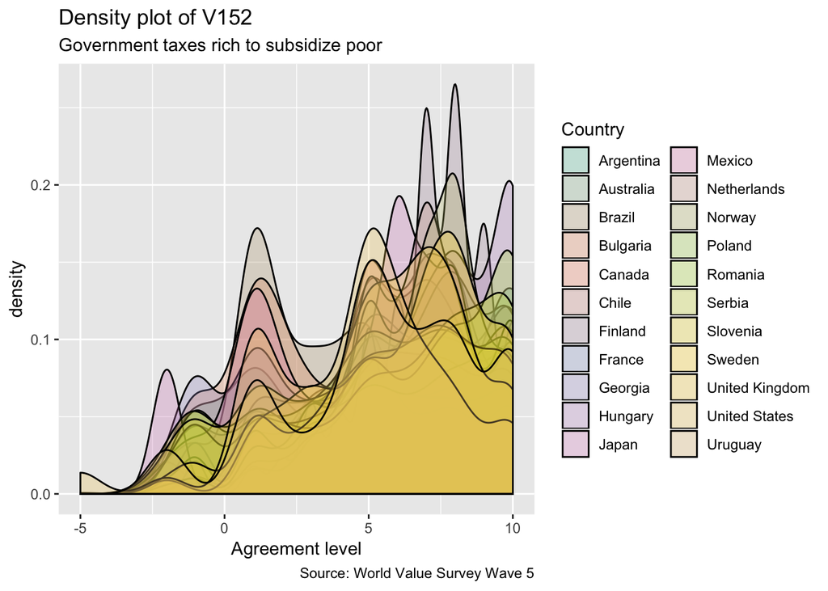

```
##        Georgia       Bulgaria         Serbia      Argentina       Slovenia
##          0.144          0.120          0.119          0.116          0.104
##         Poland          Japan          Chile        Romania         Mexico
##          0.103          0.100          0.088          0.087          0.075
##         Brazil        Uruguay         Canada United Kingdom  United States
##          0.066          0.048          0.047          0.041          0.041
##    Netherlands      Australia        Finland         Norway        Hungary
##          0.038          0.032          0.020          0.018          0.016
##         Sweden         France
##          0.014          0.013
```

**Bulgaria** and **Georgia** both have more than 20% of -1:“dont know”s; **Japan** has about 20% of -2:“No answer”

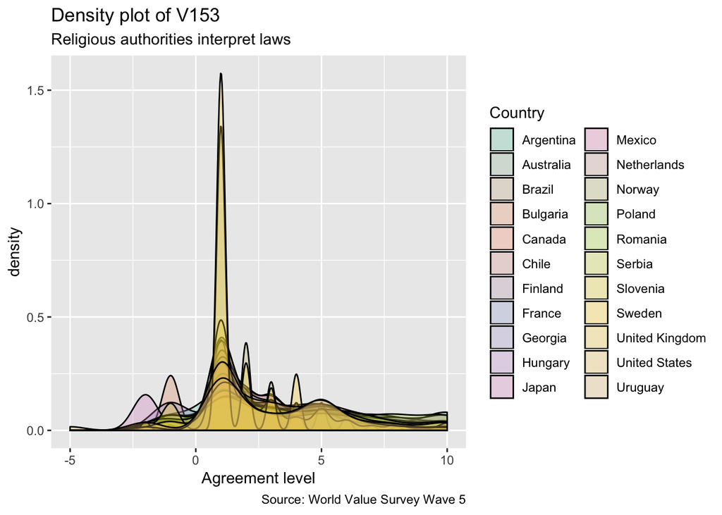

[output not shown]

V154 seems okay: the highest nonnormal peaks are **Japan** with only 9.8% and **Serbia** with 9.4%

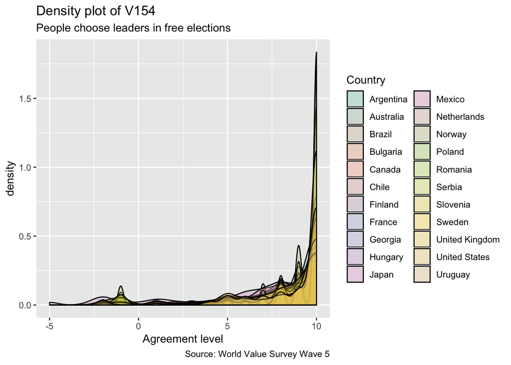

[output not shown]

V155 seems okay with **Argentina** 11.1% as nonnormal values and **Japan** 10.9% with nonnormal values

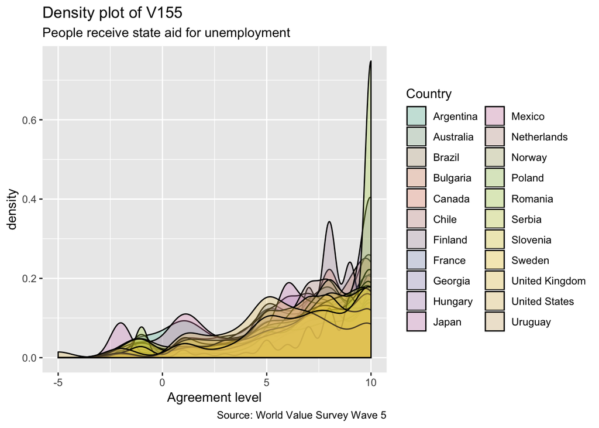

[output not shown]

In terms of V156, there are some countries with lots of -1 pr -2s. **Bulgaria** has 18.7%, **Georgia** 18.4%, **Serbia** 16.4% etc…

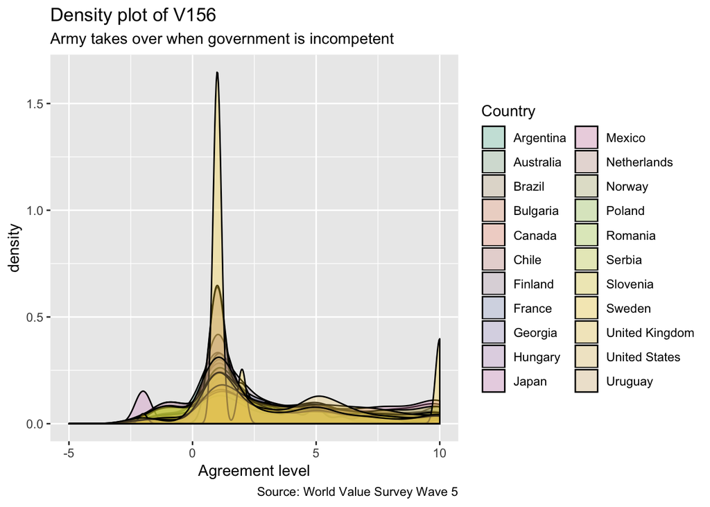

[output not shown]

For V157, **Japan**, **Bulgaria**, **Serbia** have some unnormal values

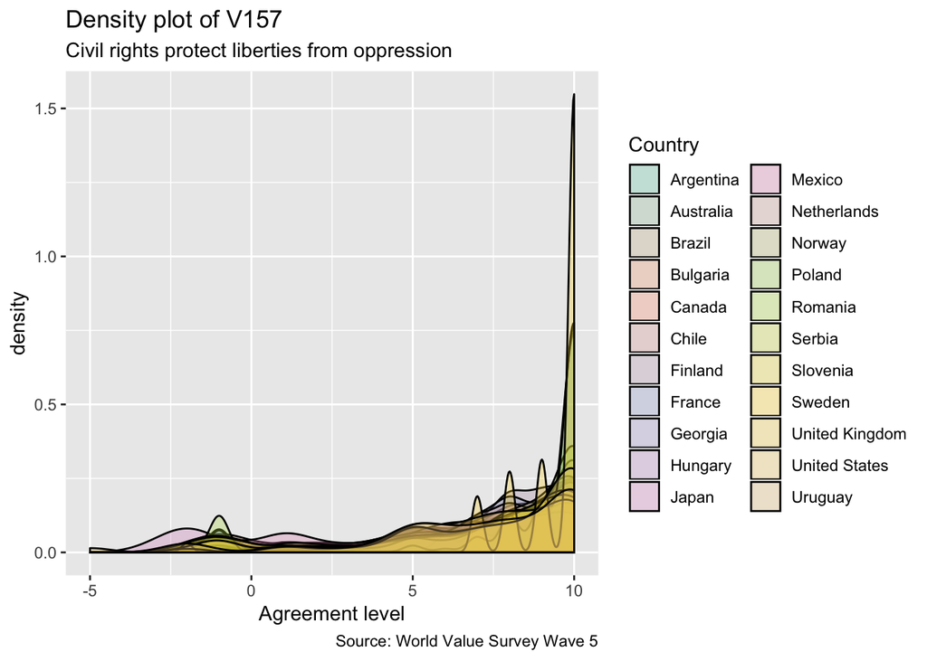

[output not shown]

The V161 seems okay with **Serbia** 9.9% and **Japan** 8.8

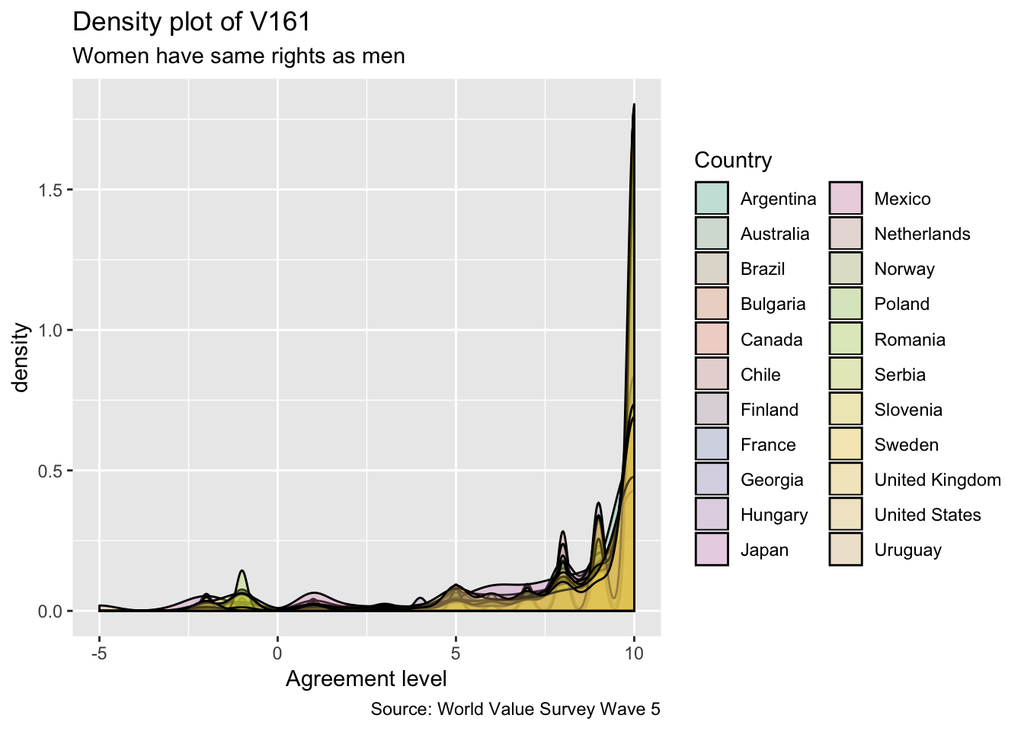

[output not shown]

For the purpose of exploratory analysis, I deleted entries with at least one answer being unnormal (<0), in those troublemaking countries: “Georgia”, “Japan”, “Bulgaria”, “Serbia”, “Slovenia.” The percentage of the normal entries that are left are such percentage:

```r
## original size
d = c()
for (cn in c("Georgia", "Japan", "Bulgaria", "Serbia", "Slovenia")){
  a = data_wv5_6up %>%
    filter(country == cn) %>%
    nrow()
  d = c(d, a)
}

print(paste("The originial size for", c("Georgia", "Japan", "Bulgaria", "Serbia", "Slovenia"), "are:", d))
```

```
## [1] "The originial size for Georgia are: 1500"
## [2] "The originial size for Japan are: 1096"
## [3] "The originial size for Bulgaria are: 1001"
## [4] "The originial size for Serbia are: 1220"
## [5] "The originial size for Slovenia are: 1037"
```

```r
## filtered size
b = c()
for (cn in c("Georgia", "Japan", "Bulgaria", "Serbia", "Slovenia")){
  a = data_wv5_6up %>%
    filter(country == cn) %>%
    filter(V152>0 & V153>0 & V154>0 & V155 >0 & V156 >0 & V157 >0 & V161>0) %>%
    nrow()
  b = c(b,a)
}

print(paste("After DELETION of nonnormal entries, the size for", c("Georgia", "Japan", "Bulgaria", "Serbia", "Slovenia"), "are:", b))
```

```
## [1] "After DELETION of nonnormal entries, the size for Georgia are: 1004"
## [2] "After DELETION of nonnormal entries, the size for Japan are: 718"
## [3] "After DELETION of nonnormal entries, the size for Bulgaria are: 693"
## [4] "After DELETION of nonnormal entries, the size for Serbia are: 958"
## [5] "After DELETION of nonnormal entries, the size for Slovenia are: 806"
```

```r
### The percentage of the normal entries for countries: "Georgia", "Japan", "Bulgaria", "Serbia", "Slovenia"

print(paste("The percentage of the normal entries that are left for", c("Georgia", "Japan", "Bulgaria", "Serbia", "Slovenia"), "are:", b/d))
```

```
## [1] "The percentage of the normal entries that are left for Georgia are: 0.669333333333333"
## [2] "The percentage of the normal entries that are left for Japan are: 0.655109489051095"
## [3] "The percentage of the normal entries that are left for Bulgaria are: 0.692307692307692"
## [4] "The percentage of the normal entries that are left for Serbia are: 0.785245901639344"
## [5] "The percentage of the normal entries that are left for Slovenia are: 0.777242044358727"
```

Surprisingly, there are lots of entries which all the answers are negative, for example in **Japan**

```r
Japan %>%
  filter(V152 < 0)
```

```
## # A tibble: 110 x 8
##    country  V152  V153  V154  V155  V156  V157  V161
##    <chr>   <dbl> <dbl> <dbl> <dbl> <dbl> <dbl> <dbl>
##  1 Japan      -2    -2    -2    -2    -2    -2    -2
##  2 Japan      -2    -2    -2    -2    -2    -2    -2
##  3 Japan      -2    -2    -2    -2    -2    -2    -2
##  4 Japan      -2    -2    -2    -2    -2    -2    -2
##  5 Japan      -2    -2    -2    -2    -2    -2    -2
##  6 Japan      -2     1     1     1    -2    -2     1
##  7 Japan      -2    -2    -2    -2    -2    -2    -2
##  8 Japan      -2    -2    -2    -2    -2    -2    -2
##  9 Japan      -2    -2    -2    -2    -2    -2    -2
## 10 Japan      -2    -2    -2    -2    -2    -2    -2
## # ... with 100 more rows
```

and **Bulgaria**

```r
data_wv5_6up %>%
  filter(country == "Bulgaria") %>%
  filter(V152 <0)
```

```
## # A tibble: 120 x 8
##    country   V152  V153  V154  V155  V156  V157  V161
##    <chr>    <dbl> <dbl> <dbl> <dbl> <dbl> <dbl> <dbl>
##  1 Bulgaria    -1    -1    -1    -1    -1    -1    -1
##  2 Bulgaria    -1    -1    -1    -1    -1    -1    -1
##  3 Bulgaria    -1    -1    -1    -1    -1    -1    -1
##  4 Bulgaria    -1    -1    -1    -1    -1    -1    -1
##  5 Bulgaria    -1    -1    10    10     1    10    10
##  6 Bulgaria    -1    -1    10    10     1     8    10
##  7 Bulgaria    -1    -1    10     8     1    10    10
##  8 Bulgaria    -1    -1    10    10     1    10    10
##  9 Bulgaria    -1    -1     9     9    -1    -1     9
## 10 Bulgaria    -1     1    10    10    -1     8    10
## # ... with 110 more rows
```

The troublemakers are mainly Japan, Bulgaria, Serbia, Georgia Slovenia etc… which are mostly eastern Europe or Asia countries. They usually have above 10% of nonnormal values in at least one of the items.

The main issue we need to deal with are those -2 and -1’s. Because there are many entries that are populated with not only one negaties, I think we might want to delete them at all.

rmarkdown::render(“Explore_nonnormal_values.Rmd”)